# week-4 graded_project-PRAKASH

# PART - 02

### IMPORT REQUIRED LIBRARIES AND READ THE DATASET

```python
import pandas as pd
import numpy as np
import matplotlib.pyplot as plt
import seaborn as sns
```

```python
df = pd.read_csv(r"C:\Users\Admin\Downloads\honeyproduction.csv")
```

```python
df.head(3)
```

|  | state | numcol | yieldpercol | totalprod | stocks | priceperlb | prodvalue | year |
| --- | --- | --- | --- | --- | --- | --- | --- | --- |
| 0 | AL | 16000.0 | 71 | 1136000.0 | 159000.0 | 0.72 | 818000.0 | 1998 |
| 1 | AZ | 55000.0 | 60 | 3300000.0 | 1485000.0 | 0.64 | 2112000.0 | 1998 |
| 2 | AR | 53000.0 | 65 | 3445000.0 | 1688000.0 | 0.59 | 2033000.0 | 1998 |

```python
df.describe().transpose()
```

|  | count | mean | std | min | 25% | 50% | 75% | max |
| --- | --- | --- | --- | --- | --- | --- | --- | --- |
| numcol | 626.0 | 6.028435e+04 | 9.107709e+04 | 2000.00 | 9000.0000 | 26000.00 | 63750.00 | 510000.00 |
| yieldpercol | 626.0 | 6.200958e+01 | 1.945875e+01 | 19.00 | 48.0000 | 60.00 | 74.00 | 136.00 |
| totalprod | 626.0 | 4.169086e+06 | 6.883847e+06 | 84000.00 | 475000.0000 | 1533000.00 | 4175250.00 | 46410000.00 |
| stocks | 626.0 | 1.318859e+06 | 2.272964e+06 | 8000.00 | 143000.0000 | 439500.00 | 1489500.00 | 13800000.00 |
| priceperlb | 626.0 | 1.409569e+00 | 6.385989e-01 | 0.49 | 0.9325 | 1.36 | 1.68 | 4.15 |
| prodvalue | 626.0 | 4.715741e+06 | 7.976110e+06 | 162000.00 | 759250.0000 | 1841500.00 | 4703250.00 | 69615000.00 |
| year | 626.0 | 2.004864e+03 | 4.317306e+00 | 1998.00 | 2001.0000 | 2005.00 | 2009.00 | 2012.00 |

### Check the first few samples, shape, info of the data and try to familiarize yourself with different features.

```python
df.shape
```

```
(626, 8)
```

```python
df.info()
```

```
<class 'pandas.core.frame.DataFrame'>
RangeIndex: 626 entries, 0 to 625
Data columns (total 8 columns):
 #   Column       Non-Null Count  Dtype
---  ------       --------------  -----
 0   state        626 non-null    object
 1   numcol       626 non-null    float64
 2   yieldpercol  626 non-null    int64
 3   totalprod    626 non-null    float64
 4   stocks       626 non-null    float64
 5   priceperlb   626 non-null    float64
 6   prodvalue    626 non-null    float64
 7   year         626 non-null    int64
dtypes: float64(5), int64(2), object(1)
memory usage: 39.3+ KB
```

```python
df.isna().sum()
```

```
state          0
numcol         0
yieldpercol    0
totalprod      0
stocks         0
priceperlb     0
prodvalue      0
year           0
dtype: int64
```

### Display the percentage distribution of the data in each year using the pie chart

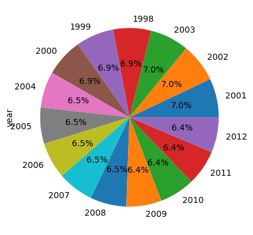

```python
df.year.value_counts().plot(kind = 'pie', autopct = '%.1f%%')
```

### Plot and Understand the distribution of the variable "price per lb" using displot, and write your findings

```python
df.columns
```

```
Index(['state', 'numcol', 'yieldpercol', 'totalprod', 'stocks', 'priceperlb',
       'prodvalue', 'year'],
      dtype='object')
```

```
<function matplotlib.pyplot.show(close=None, block=None)>
```

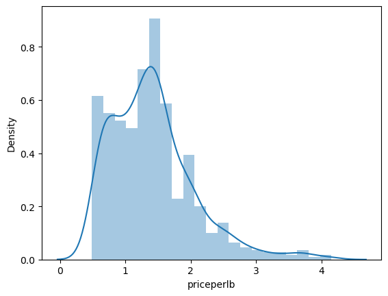

```python
sns.distplot(df['priceperlb'], kde=True, label = 'plot1')
plt.show
```

### Plot and understand the relationship between the variables 'numcol' and 'prodval' through scatterplot, and write your findings.

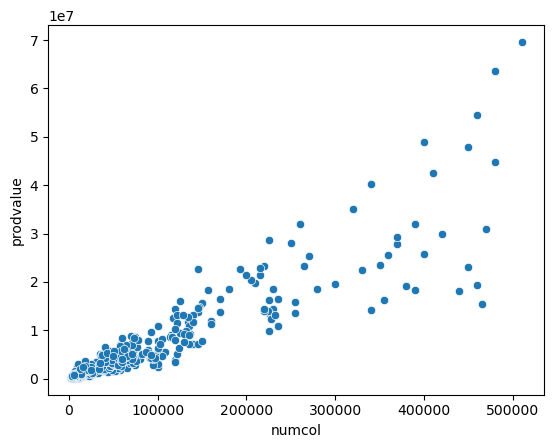

```python
sns.scatterplot(data=df, x='numcol',y='prodvalue')
```

### Plot and understand the relationship between categorical variable 'year' and a numerical variable 'prodvalue' through boxplot, and write your findings.

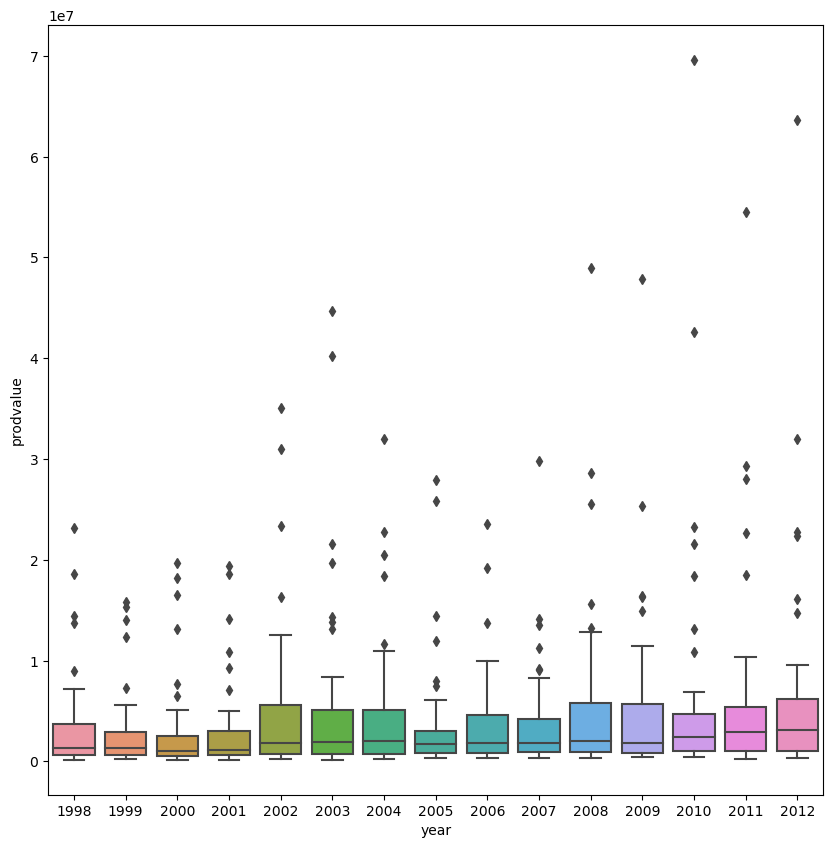

```python
plt.figure(figsize=(10,10))
sns.boxplot(data = df, x = 'year', y = 'prodvalue')
```

### Visualize and understand the relationship between the multiple pairs of variables throughout different years using pairplot and add your inferences. (use columns 'numcol', 'yield percol', 'total prod', 'prodvalue','year').

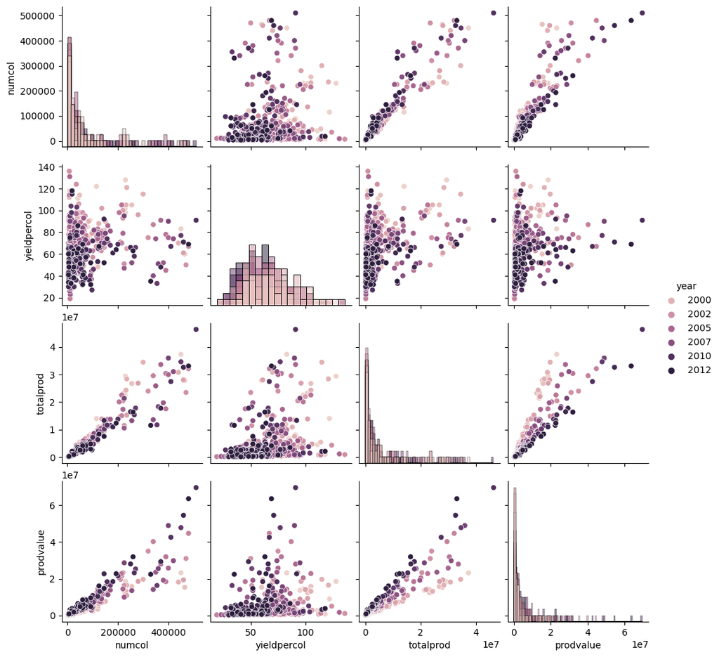

```python
columns_to_plot = ['numcol', 'yieldpercol', 'totalprod', 'prodvalue', 'year']
sns.pairplot(df[columns_to_plot], hue='year', diag_kind='hist')
plt.show()
```

```python
df.columns
```

```
Index(['state', 'numcol', 'yieldpercol', 'totalprod', 'stocks', 'priceperlb',
       'prodvalue', 'year'],
      dtype='object')
```

```python
df.corr()
```

|  | numcol | yieldpercol | totalprod | stocks | priceperlb | prodvalue | year |
| --- | --- | --- | --- | --- | --- | --- | --- |
| numcol | 1.000000 | 0.243515 | 0.953594 | 0.825929 | -0.232701 | 0.912796 | 0.008709 |
| yieldpercol | 0.243515 | 1.000000 | 0.396252 | 0.367812 | -0.358646 | 0.278977 | -0.232092 |
| totalprod | 0.953594 | 0.396252 | 1.000000 | 0.878830 | -0.264499 | 0.907236 | -0.055556 |
| stocks | 0.825929 | 0.367812 | 0.878830 | 1.000000 | -0.305867 | 0.728560 | -0.119602 |
| priceperlb | -0.232701 | -0.358646 | -0.264499 | -0.305867 | 1.000000 | -0.089567 | 0.693984 |
| prodvalue | 0.912796 | 0.278977 | 0.907236 | 0.728560 | -0.089567 | 1.000000 | 0.139451 |
| year | 0.008709 | -0.232092 | -0.055556 | -0.119602 | 0.693984 | 0.139451 | 1.000000 |

strong positive correlation: numcol and totalprod (0.953):there is a very strong positive correlation between number of honey producing colonies and total production, indicating that as the number of colonies increases, the total production also tends to increases significantly.

numcol and prodvalue (0.912): similarly a strong positive correlation exists between number of honey producing colonies and the production value , implies as higher number of colonies leads to increases the production value.

the strong and moderate relationship between the variables especailly between numcol(num of colonies),totalprod(total production), prodval(product value) and stocks. meanwile, 'yieldpercol(honey yield per colony) and priceperlb show weaker assocaition with other variables in the given dataset.